# Gáficos interactivos

## Librería Plotly

Esta librería crea gráficos interactivos con calidad de publicación. Puede crear gráficos de líneas, de dispersión, de áreas, de barras, de barras de error, de caja, histogramas, mapas de calor, subgráficos, ejes múltiples y gráficos 3D.

- [Galería de gráficos plotly](https://plotly.com/r/)

```r
nombres_arg <- read.csv("Bases de datos/historico-nombres.csv")
```

```r
df_graficar_anio <- nombres_arg %>%
  filter(
    nombre %in% c("Juan", "Maria", "Emilio", "Eva"),
    anio >= 1950,
    anio <  2010
  ) %>%
  select(-X) %>%
  mutate(decada = anio %/% 10 * 10)

df_graficar_decada <- df_graficar_anio %>%
  select(-anio) %>%
  group_by(nombre, decada) %>%
  summarise(cantidad = sum(cantidad))

ggplotly(
    ggplot(
        data = df_graficar_decada, mapping = aes(x = decada, y= cantidad, fill = nombre)
    ) +
      geom_col(position = "fill")+
      theme_classic())
```

[interactive chart not shown]

```r
ggplotly(
  ggplot(data = df_graficar_anio) +
  geom_boxplot(mapping = aes(x = nombre, y = cantidad, fill = nombre)) +
  facet_wrap(~decada) +
  theme_bw()
)
```

[interactive chart not shown]

Trabajamos con la base **paises**

```r
paises <- read.csv("Bases de datos/paises.csv", sep =";")
```

```r
library(hrbrthemes)
paises <- read.csv("Bases de datos/paises.csv", sep =";")

p <- paises %>%
        ggplot(aes(Tasa_de_crecimiento, y= Poblacion_urbana, size = Poblacion_2020,
                    color = Continente, text= Pais)) +
        geom_point(alpha = 0.7) +
        scale_size(range = c(1, 5)) +
        theme_ipsum()
ggplotly(p)
```

[interactive chart not shown]

## Librería gganimate

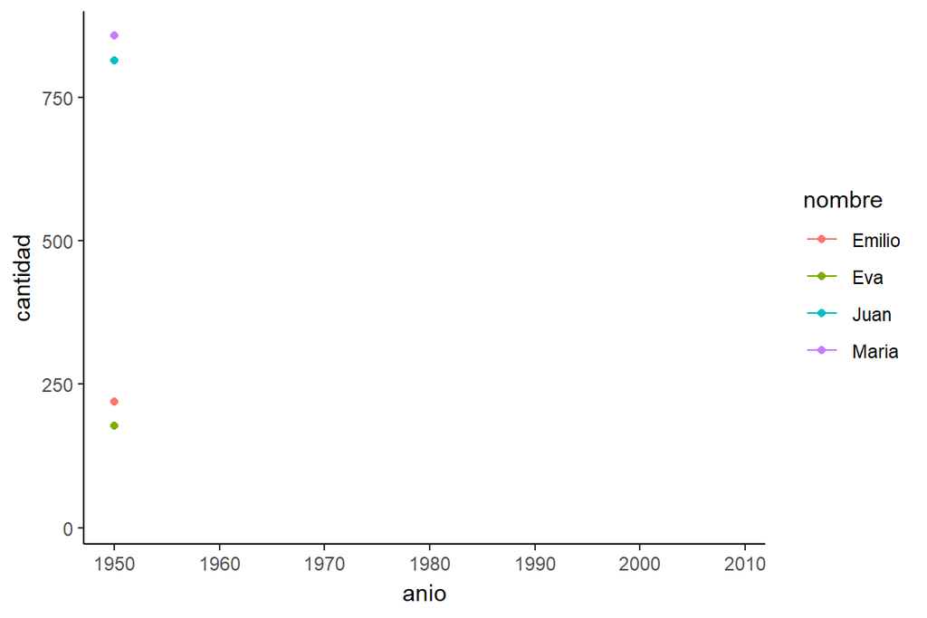

```r
library(gganimate)
library(gifski)

anim <- ggplot(
    data = df_graficar_anio,
    aes(x = anio, y = cantidad, color = nombre)) +
  geom_line() +
  geom_point() +
  theme_classic() +
  transition_reveal(anio)

animate(anim, nframes = 200, , fps = 10,
        renderer = gifski_renderer("gganim.gif"))
```

Utilizamos la base de datos **Gapminder**

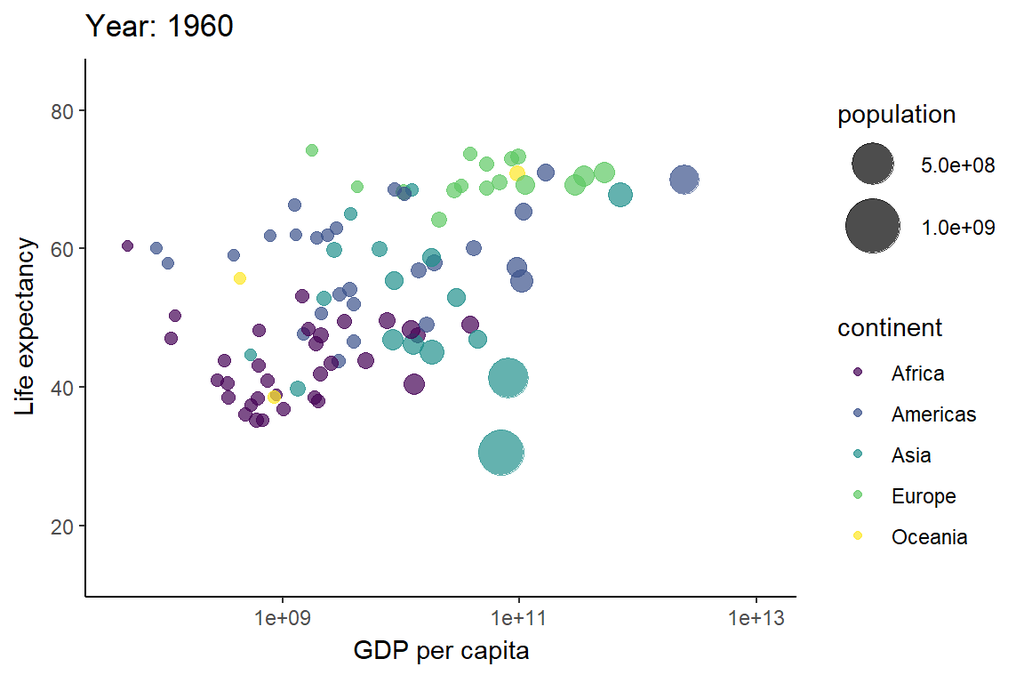

```r
library(dslabs)
data("gapminder")

p <- ggplot(
  gapminder,
  aes(x = gdp, y=life_expectancy, size = population, colour = continent)
  ) +
  geom_point(show.legend = TRUE, alpha = 0.7) +
  scale_color_viridis_d() +
  scale_size(range = c(2, 12)) +
  scale_x_log10() +
  theme_classic() +
  labs(x = "GDP per capita", y = "Life expectancy")



p + transition_time(year) +
  labs(title = "Year: {frame_time}")
```

```r
df <- gapminder::gapminder

fig <- df %>%
  plot_ly(
    x = ~gdpPercap,
    y = ~lifeExp,
    size = ~pop,
    color = ~continent,
    frame = ~year,
    text = ~country,
    hoverinfo = "text",
    type = 'scatter',
    mode = 'markers'
  )
fig <- fig %>% layout(
    xaxis = list(
      type = "log"
    )
  )

fig
```

[interactive chart not shown]

### Ejercitación

Cargar la base de datos **Titanic** y responder las siguientes preguntas.

-¿Los que estuvieron en la primera clase tuvieron más posibilidades de sobrevivir? -¿Sobrevivieron más mujeres y jóvenes que hombres? -¿Cuál fue la clase que tuvo mayor variabilidad en cuanto a las edades de los pasajeros? -Comparar las distribuciones de las edades entre los que sobrevivieron y no sobrevivieron, ¿existen diferencias? -¿Existe relación entre el costo del ticket y la edad?

Cargar la base de datos **ecobicis**

-Visualizar las diferencias, en cuanto al género, de la evolución de la cantidad en el uso de las bicicletas durante el mes de marzo. -Detectar cuál fue el horario en el que más se utilizaron las bicicletas.